# Lab 2

Neha Maddali

9/16/2021

## Reading in the data

```r
library(classdata)
data(choco)
str(choco)
```

```
## Classes 'tbl_df', 'tbl' and 'data.frame':    2452 obs. of  13 variables:
##  $ REF               : num  2454 2458 2454 2542 2546 ...
##  $ Company           : chr  "5150" "5150" "5150" "5150" ...
##  $ Location          : chr  "U.S.A." "U.S.A." "U.S.A." "U.S.A." ...
##  $ ReviewDate        : num  2019 2019 2019 2021 2021 ...
##  $ CountryBeanOrigin : chr  "Tanzania" "Dominican Republic" "Madagascar" "Fiji" ...
##  $ SpecificBeanOrigin: chr  "Kokoa Kamili, batch 1" "Zorzal, batch 1" "Bejofo Estate, batch 1" "Matasawalevu, batch 1" ...
##  $ Ingredients       : chr  "3- B,S,C" "3- B,S,C" "3- B,S,C" "3- B,S,C" ...
##  $ Characteristics1  : chr  "rich cocoa" "cocoa" "cocoa" "chewy" ...
##  $ Characteristics2  : chr  "fatty" "vegetal" "blackberry" "off" ...
##  $ Characteristics3  : chr  "bready" "savory" "full body" "rubbery" ...
##  $ Characteristics4  : chr  NA NA NA NA ...
##  $ Rating            : num  3.25 3.5 3.75 3 3 3.25 3.5 3.5 3.75 2.75 ...
##  $ CocoaPercent      : num  76 76 76 68 72 80 68 70 63 70 ...
```

## Searching for the Best Chocolates

1. How are the cocoa percent distributed? Create both a histogram and a boxplot and describe them. Don’t forget to mention outliers, if there are any.

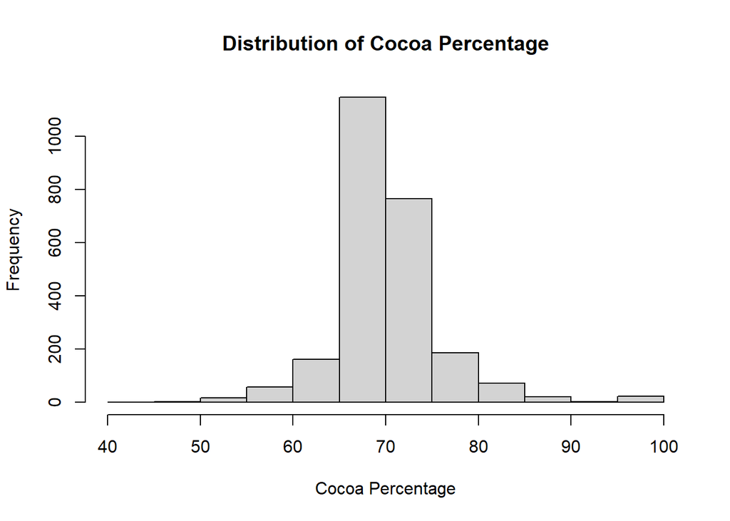

```r
hist(choco$CocoaPercent, main="Distribution of Cocoa Percentage", xlab="Cocoa Percentage")
```

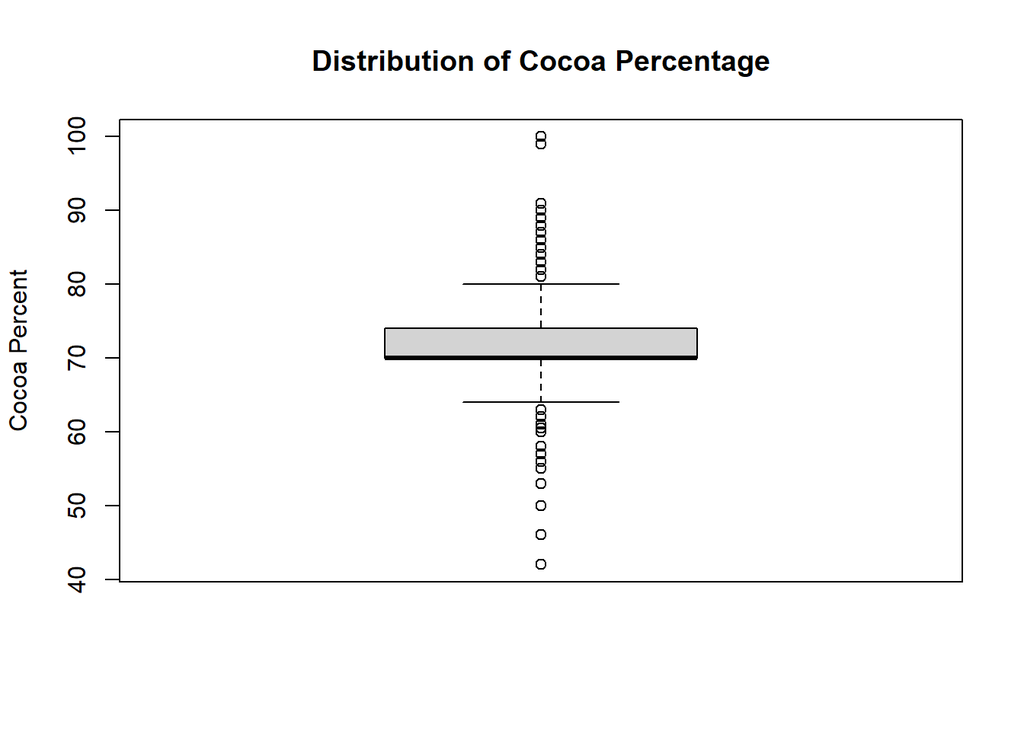

```r
boxplot(choco$CocoaPercent, main="Distribution of Cocoa Percentage", ylab="Cocoa Percent")
```

2. How does the number of ratings depend on the country of bean origin? Draw a bar chart of the number of ratings by bean origin. [Hint: If your graph is too dense and the labels are not legible, show fewer bean origins.]

```r
#lvl <- c('2006', '2007','2008','2009','2010','2011','2012','2013','2014','2015',
 #        '2016','2017','2018','2019','2020','2021')
#lvl <- c(choco$CountryBeanOrigin)
#chocoYears <- factor(choco$ReviewDate, levels = lvl)
#barplot(table(chocoYears), xlab = 'Country of Bean Origin', ylab = 'Number of Ratings', main = 'Number of Ratings by Country of Bean Origin', ylim = c(0,300), las = 2)

origin <- choco[c("CountryBeanOrigin", "Rating")]
topO <- origin[origin$Rating == 4,]
```

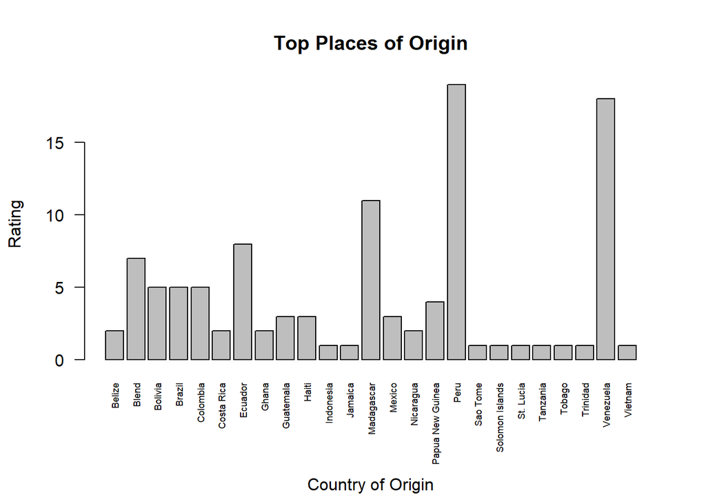

```r
par(mar=c(7, 4.2, 4.2, 2.4))
barplot(table(topO$CountryBeanOrigin), las=2, cex.names=0.55)
title(main="Top Places of Origin", xlab="", ylab="Rating")
mtext(text = 'Country of Origin',side=1, line= 5.5)
```

**Analysis** It can be seen in the barplot that Peru had the most highest ratings. Venezuela was really close and came in second most ratings.

3. Do ratings depend on the cocoa percentage of a chocolate bar? Create both numerical and graphical summaries, and explain. [Hint: Think about why the scatterplot is not a very good choice for visualization here.]

```r
percent <- choco[c("CocoaPercent","Rating")]
summary(percent)
```

```
##   CocoaPercent        Rating
##  Min.   : 42.00   Min.   :1.000
##  1st Qu.: 70.00   1st Qu.:3.000
##  Median : 70.00   Median :3.250
##  Mean   : 71.65   Mean   :3.192
##  3rd Qu.: 74.00   3rd Qu.:3.500
##  Max.   :100.00   Max.   :4.000
```

```r
str(percent)
```

```
## Classes 'tbl_df', 'tbl' and 'data.frame':    2452 obs. of  2 variables:
##  $ CocoaPercent: num  76 76 76 68 72 80 68 70 63 70 ...
##  $ Rating      : num  3.25 3.5 3.75 3 3 3.25 3.5 3.5 3.75 2.75 ...
```

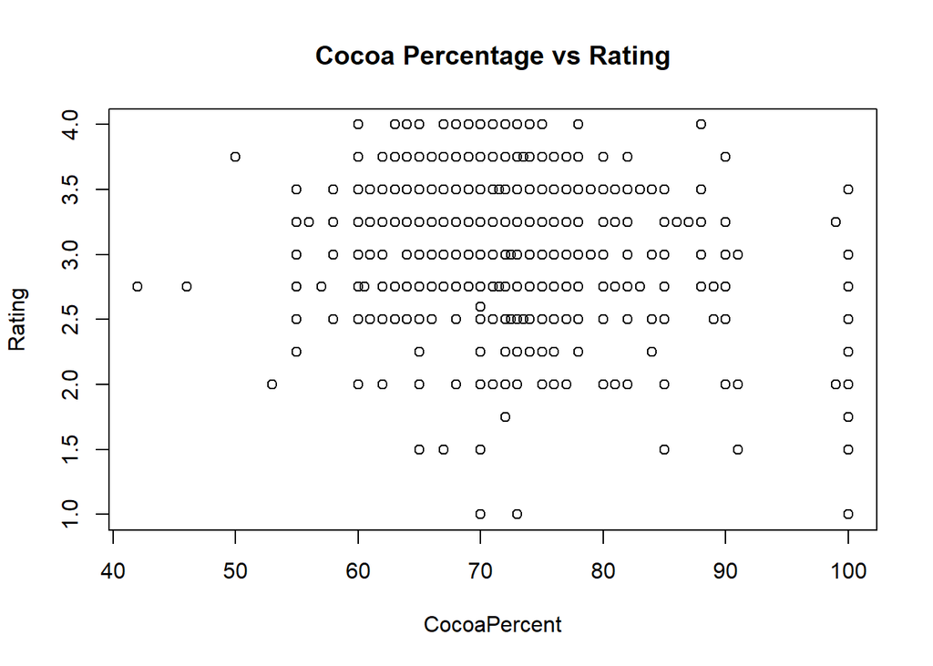

```r
plot(percent)
title(main="Cocoa Percentage vs Rating")
```

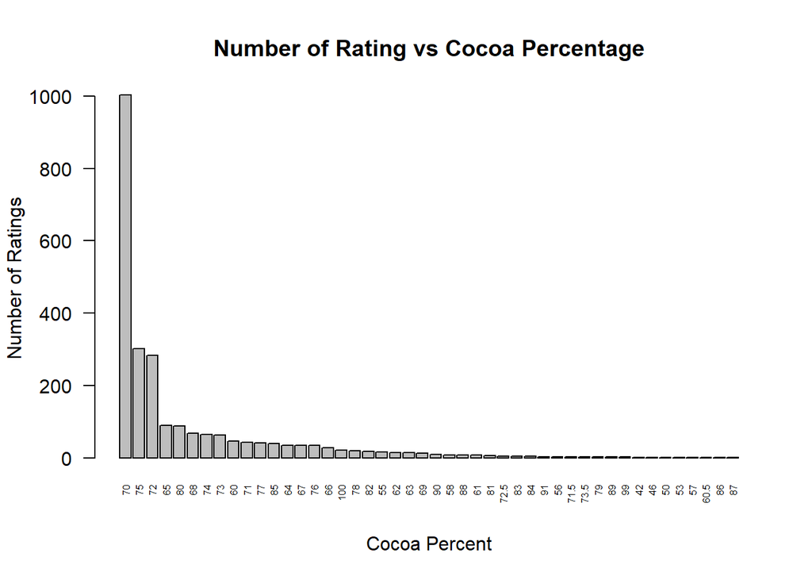

```r
cocoa <- sort(table(choco$CocoaPercent), decreasing = TRUE)
cocoapercent <- head(cocoa, 20)

barplot(cocoa, las =2, cex.names = 0.5, main = "Number of Rating vs Cocoa Percentage", xlab = "Cocoa Percent", ylab = "Number of Ratings")
```

**Analysis** From the scatterplot, there doesn’t seem too much of a correlation between cocoa percentage and rating. Using a barplot, we can see that there are the most ratings with a Cocoa Percent of 70.

4. How do different bean origins compare in terms of the flavor of chocolates? Are beans from some places better than the other? Create both numerical and graphical summaries, and explain.

```r
choco$Characteristics1 <- as.factor(choco$Characteristics1)
head(sort(table(choco$Characteristics1), decreasing = TRUE), n = 20)
```

```
##
##     creamy      sandy    intense      nutty      sweet      fatty     sticky
##        162        140         85         82         80         78         63
##        dry      spicy     gritty       oily     roasty     floral     earthy
##         58         57         54         50         50         49         42
##      cocoa   molasses    complex rich cocoa     smooth     grassy
##         38         35         30         24         24         23
```

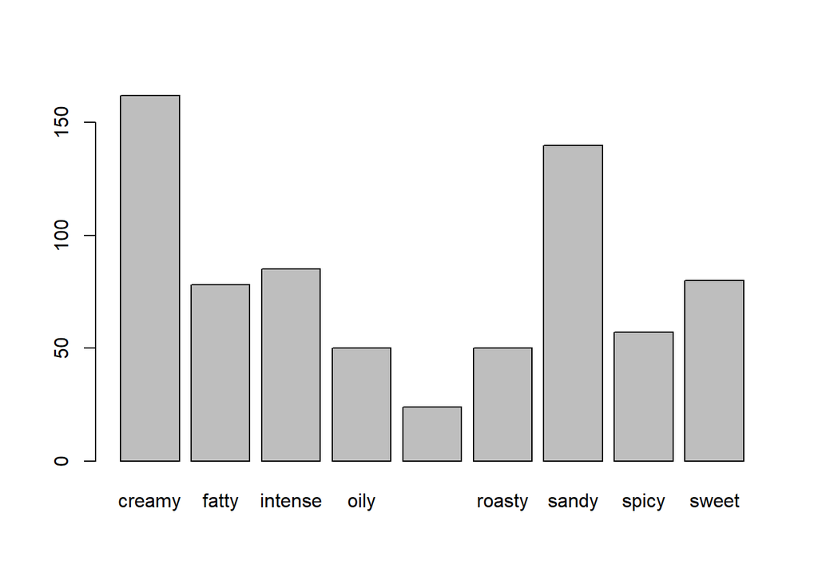

```r
choco.flavorSub = choco[choco$Characteristics1 %in% c('creamy', 'sandy','intense','nuty','fatty','sweet',                                              'spicy', 'oily' ,'roasty', 'rich cocoa'),]
choco.flavorSub$Test <- as.character(choco.flavorSub$Characteristics1)
choco.flavorSub$Test <- as.factor(choco.flavorSub$Test)

barplot(table(choco.flavorSub$Test))
```

```r
country_filtered <- table(choco$CountryBeanOrigin)
head(sort(country_filtered, decreasing = TRUE), n=5)
```

```
##
##          Venezuela               Peru Dominican Republic            Ecuador
##                247                234                220                219
##         Madagascar
##                170
```

```r
head(tapply(choco$Rating, choco$CountryBeanOrigin, summary),n=5)
```

```
## $Australia
##    Min. 1st Qu.  Median    Mean 3rd Qu.    Max.
##    2.75    3.00    3.25    3.25    3.50    3.75
##
## $Belize
##    Min. 1st Qu.  Median    Mean 3rd Qu.    Max.
##   2.500   3.000   3.250   3.236   3.500   4.000
##
## $Blend
##    Min. 1st Qu.  Median    Mean 3rd Qu.    Max.
##   1.000   2.750   3.000   3.037   3.500   4.000
##
## $Bolivia
##    Min. 1st Qu.  Median    Mean 3rd Qu.    Max.
##   2.000   3.000   3.250   3.175   3.500   4.000
##
## $Brazil
##    Min. 1st Qu.  Median    Mean 3rd Qu.    Max.
##   1.750   3.000   3.250   3.263   3.500   4.000
```

5. Brainstorm two analyses you would like to perform. Describe in plain language what comparisons are you making. Create suitable numerical and graphical summaries for your analyses. Describe the results.

**Analysis 1** I wanted to see which company had the most highest rated chocolate. From the plotting, we can see that the company “Soma” has the most counts of 4.0 rated chocolate with 13 data entries. Since I chose to look at the top rated chocolates, I only looked at data entries that had a 4.0 rating. This analysis suggests that the company may have an effect on the rating of chocolate, since the chocolates rated 4.0 were not distributed evenly between companies.

```r
company <- choco[c("Company", "Rating")]
topC <- company[company$Rating == 4,]
```

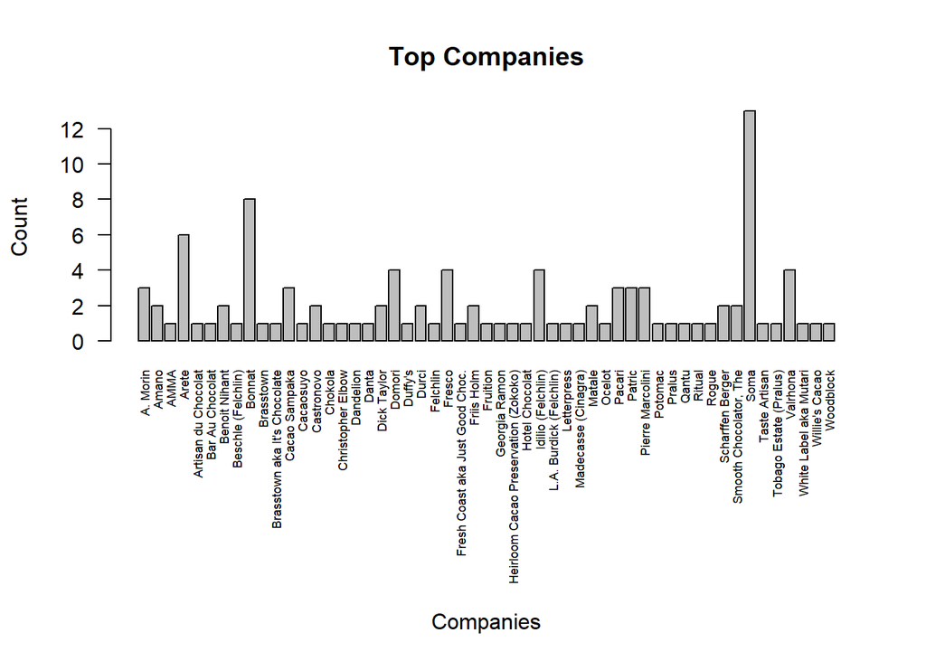

```r
par(mar=c(12, 4.2, 4.2, 2.4))
barplot(table(topC$Company), las=2, cex.names=0.55, main ='Top Companies', xlab ='', ylab = 'Count')
mtext(text = 'Companies',side=1, line= 10.0)
```

```r
top_company <- sum(topC == 'Soma')
top_company
```

```
## [1] 13
```

**Analysis 2** I was interested to see if a certain set of ingredients tended to produce chocolate bars with higher ratings.To begin, I searched for the ingredient profiles with the most entries and subsetted a vector containing only those entries, leaving out chocolate bars with very uinque ingredient profiles. I then subsetted the dataframe to contain only those ingredient profiles. From there, I created a boxplot, showing the distributions of ratings for each ingredient profile. From the plot, Ingredient profiles 2-B,S, 3-B,S,C,and B,S,C,L tended to perform slighly better. The introduction of V,into the ingredient profile did seem to decrease the performance overall. Additionally, Ingredient profile 5- B,S,C,V,L had the highest IQR of any ingredient profile,illustrated in the summary statistics.

```r
sort(table(choco$Ingredients), decreasing = TRUE)
IngredientVec <- c('2- B,S','3- B,S,C','4- B,S,C,L','4- B,S,C,V','5- B,S,C,V,L')
choco.SubIngredients = choco[choco$Ingredients %in% IngredientVec ,]
choco.SubIngredients$Factor = as.factor(choco.SubIngredients$Ingredients)
```

[output not shown]

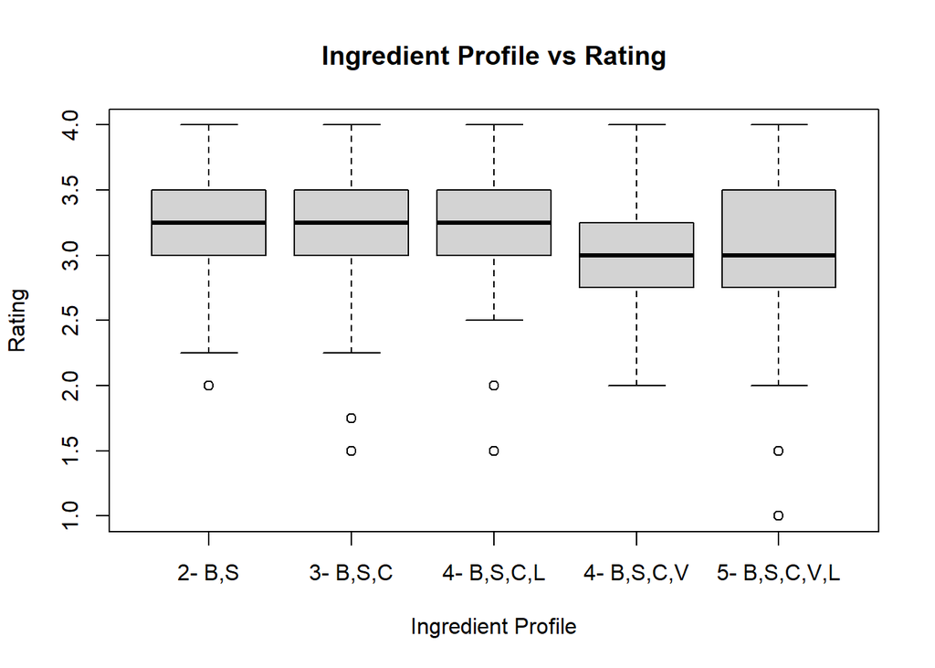

```r
boxplot(choco.SubIngredients$Rating ~ choco.SubIngredients$Factor, xlab = 'Ingredient Profile',ylab = 'Rating', main = 'Ingredient Profile vs Rating')
```

```r
summary(choco.SubIngredients$Rating[choco.SubIngredients$Ingredients == '2- B,S'])
```

```
##    Min. 1st Qu.  Median    Mean 3rd Qu.    Max.
##   2.000   3.000   3.250   3.228   3.500   4.000
```

```r
summary(choco.SubIngredients$Rating[choco.SubIngredients$Ingredients == '3- B,S,C'])
```

```
##    Min. 1st Qu.  Median    Mean 3rd Qu.    Max.
##   1.500   3.000   3.250   3.276   3.500   4.000
```

```r
summary(choco.SubIngredients$Rating[choco.SubIngredients$Ingredients == '4- B,S,C,L'])
```

```
##    Min. 1st Qu.  Median    Mean 3rd Qu.    Max.
##   1.500   3.000   3.250   3.208   3.500   4.000
```

```r
summary(choco.SubIngredients$Rating[choco.SubIngredients$Ingredients == '4- B,S,C,V'])
```

```
##    Min. 1st Qu.  Median    Mean 3rd Qu.    Max.
##   2.000   2.750   3.000   2.973   3.250   4.000
```

```r
summary(choco.SubIngredients$Rating[choco.SubIngredients$Ingredients == '5- B,S,C,V,L'])
```

```
##    Min. 1st Qu.  Median    Mean 3rd Qu.    Max.
##    1.00    2.75    3.00    3.09    3.50    4.00
```